# Spatial analytics take home assignment

# Make a GIF over time

```python
def save_frames(dataframes, dates, figsize, title, frames_dir="frames", fontsize=26, cmap='Greens', gamma=1./4., color_bar=True, pct_missing=False):
    if not os.path.exists(frames_dir):
        os.makedirs(frames_dir)
    for df, date in zip(dataframes, dates):
        pct_na = df[df == 999999.000000].count().sum() / (df.shape[0] * df.shape[1])
        fig, ax = plt.subplots(figsize=figsize)
        plt.imshow(df, cmap, norm=colors.PowerNorm(gamma), vmin=0, vmax=90)
        if color_bar:
            plt.colorbar()
        if pct_missing:
            plt.title(title + " " + date + "\n Percent Missing: " + "{0:.0%}".format(pct_na), fontsize=fontsize);
        else:
            plt.title(title + " " + date, fontsize=fontsize)
        plt.axis('off')
        plt.savefig(os.path.join(frames_dir, date), bbox_inches='tight')
        plt.close()
```

```python
%%time
save_frames(dataframes, dates, figsize=(20,10), title="Sea Surface Chlorophyll-a: ")
```

```
CPU times: user 4min 23s, sys: 43.9 s, total: 5min 7s
Wall time: 3min 15s
```

```python
def make_gif(gif_name, input_dir, output_dir, fps = 5):
    # Gather still frames
    file_list = glob.glob(os.path.join(input_dir, '*.png'))
    clip = mpy.ImageSequenceClip(file_list, fps=fps)
    # Create output folder
    if not os.path.exists(output_dir):
        os.makedirs(output_dir)
    # Write gif
    clip.write_gif(os.path.join(output_dir, '{}.gif'.format(gif_name)), fps=fps)
```

```python
%%time
make_gif("chlorophyll", "frames_chlorophyll", "movies")
```

```python
Image("https://media.giphy.com/media/eIyFna3IDcsE4imkFd/source.gif")
```

# Plot the mean chlorophyll-a concentration

```python
def calc_mean(dataframes):

    # Create a dataframe full of zeros
    zeros = dataframes[0].copy()
    zeros.loc[:,:] = 0

    # Sum over each data frame
    for df in dataframes:
        df_ = df.fillna(0)
        zeros += df_

    # Divide by number of data frames
    mean = zeros / len(dataframes)
    return mean
```

```python
mean_chlorophyll = calc_mean(dataframes)
```

```python
mean_chlorophyll.head()
```

| lat | -99.98147719379486 | -99.89812456587174 | -99.8147719379486 | -99.73141931002547 | -99.64806668210234 | -99.56471405417922 | -99.48136142625609 | -99.39800879833295 | -99.31465617040982 | -99.23130354248669 | ... | -0.7918499652697619 | -0.7084973373466141 | -0.6251447094234948 | -0.541792081500347 | -0.4584394535772276 | -0.3750868256541082 | -0.29173419773096043 | -0.20838156980784106 | -0.1250289418847217 | -0.041676313961573896 |
| --- | --- | --- | --- | --- | --- | --- | --- | --- | --- | --- | --- | --- | --- | --- | --- | --- | --- | --- | --- | --- | --- |
| 69.990736 | 0.040375 | 0.043099 | 0.041977 | 0.041929 | 0.039286 | 0.039203 | 0.042357 | 0.043167 | 0.045592 | 0.050574 | ... | 0.237992 | 0.242632 | 0.242878 | 0.233092 | 0.240585 | 0.238384 | 0.231897 | 0.236785 | 0.243385 | 0.244889 |
| 69.907365 | 0.038116 | 0.037842 | 0.043609 | 0.042649 | 0.042868 | 0.043561 | 0.047806 | 0.050664 | 0.050893 | 0.052236 | ... | 0.229537 | 0.242400 | 0.248091 | 0.251384 | 0.255671 | 0.237362 | 0.231387 | 0.238715 | 0.236362 | 0.234315 |
| 69.823993 | 0.039546 | 0.045911 | 0.047763 | 0.047917 | 0.047555 | 0.045117 | 0.048924 | 0.048360 | 0.047361 | 0.049319 | ... | 0.242054 | 0.249264 | 0.250406 | 0.237857 | 0.241545 | 0.244498 | 0.236804 | 0.235514 | 0.235493 | 0.226232 |
| 69.740621 | 0.044935 | 0.045515 | 0.047393 | 0.046591 | 0.044980 | 0.045427 | 0.040231 | 0.039735 | 0.049662 | 0.050561 | ... | 0.254862 | 0.247309 | 0.249945 | 0.242057 | 0.245450 | 0.238895 | 0.253973 | 0.249523 | 0.238742 | 0.242563 |
| 69.657249 | 0.047711 | 0.047505 | 0.043053 | 0.046328 | 0.049819 | 0.048391 | 0.049870 | 0.054745 | 0.048815 | 0.045498 | ... | 0.247613 | 0.248699 | 0.250202 | 0.250086 | 0.245574 | 0.238550 | 0.245938 | 0.249002 | 0.241428 | 0.256598 |

5 rows × 1200 columns

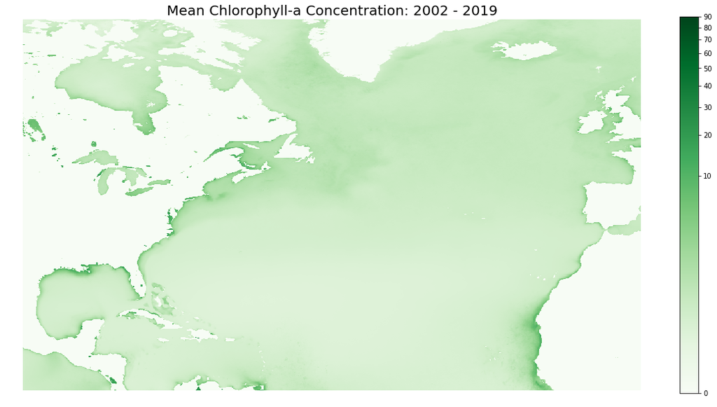

```python
fig, ax = plt.subplots(figsize=(20,10))
plt.imshow(mean_chlorophyll, cmap='Greens', norm=colors.PowerNorm(gamma=1./4.), vmin=0, vmax=90)
plt.colorbar()
plt.axis('off')
plt.title("Mean Chlorophyll-a Concentration: 2002 - 2019", fontsize=20);
```

# Open Water GeoTIFF

We need to categorize the coordinates in our dataset as *water* or *not water* so that we can discard coordinates on land from our missing data analysis.

Data source: https://www.earthenv.org/landcover

```python
src = rasterio.open(os.path.join('data','consensus_full_class_12.tif'))
```

```python
src.width
```

```
43200
```

```python
src.height
```

```
17520
```

```python
src.meta
```

```
{'driver': 'GTiff',
 'dtype': 'uint8',
 'nodata': 255.0,
 'width': 43200,
 'height': 17520,
 'count': 1,
 'crs': CRS.from_dict(init='epsg:4326'),
 'transform': Affine(0.008333333333333335, 0.0, -180.00000000000003,
        0.0, -0.008333333333333335, 90.00000000000001)}
```

```python
src.bounds
```

```
BoundingBox(left=-180.00000000000003, bottom=-56.000000000000014, right=180.00000000000003, top=90.00000000000001)
```

```python
band1 = src.read(1)
```

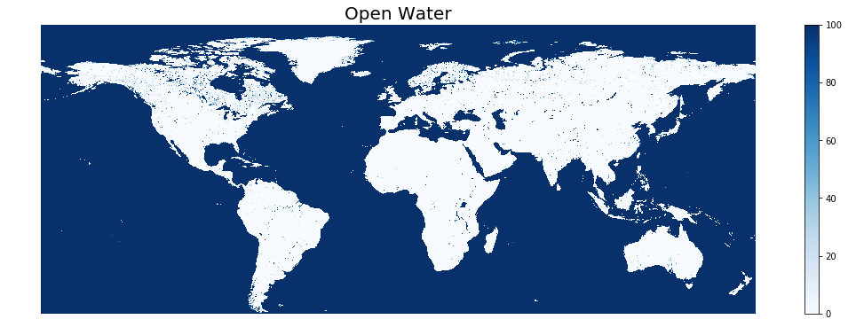

```python
fig, ax = plt.subplots(figsize=(20,6))
plt.imshow(band1, cmap='Blues', norm=colors.PowerNorm(gamma=1./1.))
plt.colorbar()
plt.axis('off')
plt.title("Open Water", fontsize=20);
```

# Classify gridded data as water or not water

We need to distinguish between coordinates that are on land versus those on water in order to assess trends in missing data.

```python
def water_or_not_water(src, df):

    # Create a dataframe full of zeros
    water_values = df.copy()
    water_values.loc[:,:] = 0

    lats = list(df.index)
    lons = list(df.columns)

    # Sample the open water raster for each pair of coordinates
    for lat in lats:
        for lon in lons:
            y = float(lat)
            x = float(lon)
            water_val = list(src.sample([(x, y)]))[0]
            water_values.loc[lat, lon] = water_val

    return water_values
```

```python
%%time
water_values = water_or_not_water(src, dataframes[0])
```

```
CPU times: user 4min 11s, sys: 1.62 s, total: 4min 13s
Wall time: 4min 13s
```

```python
water_values.head()
```

| lat | -99.98147719379486 | -99.89812456587174 | -99.8147719379486 | -99.73141931002547 | -99.64806668210234 | -99.56471405417922 | -99.48136142625609 | -99.39800879833295 | -99.31465617040982 | -99.23130354248669 | ... | -0.7918499652697619 | -0.7084973373466141 | -0.6251447094234948 | -0.541792081500347 | -0.4584394535772276 | -0.3750868256541082 | -0.29173419773096043 | -0.20838156980784106 | -0.1250289418847217 | -0.041676313961573896 |
| --- | --- | --- | --- | --- | --- | --- | --- | --- | --- | --- | --- | --- | --- | --- | --- | --- | --- | --- | --- | --- | --- |
| 69.990736 | 100.0 | 100.0 | 100.0 | 100.0 | 100.0 | 100.0 | 100.0 | 100.0 | 100.0 | 100.0 | ... | 100.0 | 100.0 | 100.0 | 100.0 | 100.0 | 100.0 | 100.0 | 100.0 | 100.0 | 100.0 |
| 69.907365 | 100.0 | 100.0 | 100.0 | 100.0 | 100.0 | 100.0 | 100.0 | 100.0 | 100.0 | 100.0 | ... | 100.0 | 100.0 | 100.0 | 100.0 | 100.0 | 100.0 | 100.0 | 100.0 | 100.0 | 100.0 |
| 69.823993 | 100.0 | 100.0 | 100.0 | 100.0 | 100.0 | 100.0 | 100.0 | 100.0 | 100.0 | 100.0 | ... | 100.0 | 100.0 | 100.0 | 100.0 | 100.0 | 100.0 | 100.0 | 100.0 | 100.0 | 100.0 |
| 69.740621 | 100.0 | 100.0 | 100.0 | 100.0 | 100.0 | 100.0 | 100.0 | 100.0 | 100.0 | 100.0 | ... | 100.0 | 100.0 | 100.0 | 100.0 | 100.0 | 100.0 | 100.0 | 100.0 | 100.0 | 100.0 |
| 69.657249 | 100.0 | 100.0 | 100.0 | 100.0 | 100.0 | 100.0 | 100.0 | 100.0 | 100.0 | 100.0 | ... | 100.0 | 100.0 | 100.0 | 100.0 | 100.0 | 100.0 | 100.0 | 100.0 | 100.0 | 100.0 |

5 rows × 1200 columns

```python
water_values.shape
```

```
(720, 1200)
```

```python
water_values['lat'] = water_values.index
```

```python
water_values_long = pd.melt(water_values, id_vars=['lat'])
```

```python
water_values_long.head()
```

|  | lat | variable | value |
| --- | --- | --- | --- |
| 0 | 69.990736 | -99.98147719379486 | 100.0 |
| 1 | 69.907365 | -99.98147719379486 | 100.0 |
| 2 | 69.823993 | -99.98147719379486 | 100.0 |
| 3 | 69.740621 | -99.98147719379486 | 100.0 |
| 4 | 69.657249 | -99.98147719379486 | 100.0 |

# Set Land coords equal to pixes with < 10 water value

```python
land_coords_long = water_values_long[water_values_long['value'] < 10].copy()
```

```python
land_coords_long.shape
```

```
(238947, 3)
```

```python
land_coords_long.head()
```

|  | lat | variable | value |
| --- | --- | --- | --- |
| 27 | 67.739694 | -99.98147719379486 | 0.0 |
| 28 | 67.656322 | -99.98147719379486 | 0.0 |
| 29 | 67.572950 | -99.98147719379486 | 0.0 |
| 30 | 67.489579 | -99.98147719379486 | 0.0 |
| 31 | 67.406207 | -99.98147719379486 | 0.0 |

```python
land_coords_wide = land_coords_long.pivot(index='lat', columns='variable')
```

```python
land_coords_wide.head()
```

| variable lat | value -0.041676313961573896 | value -0.1250289418847217 | value -0.20838156980784106 | value -0.29173419773096043 | value -0.3750868256541082 | value -0.4584394535772276 | value -0.541792081500347 | value -0.6251447094234948 | value -0.7084973373466141 | value -0.7918499652697619 | value ... | value -99.23130354248669 | value -99.31465617040982 | value -99.39800879833295 | value -99.48136142625609 | value -99.56471405417922 | value -99.64806668210234 | value -99.73141931002547 | value -99.8147719379486 | value -99.89812456587174 | value -99.98147719379486 |
| --- | --- | --- | --- | --- | --- | --- | --- | --- | --- | --- | --- | --- | --- | --- | --- | --- | --- | --- | --- | --- | --- |
| 10.046318 | 0.0 | 0.0 | 0.0 | 0.0 | 0.0 | 0.0 | 0.0 | 0.0 | 0.0 | 0.0 | ... | NaN | NaN | NaN | NaN | NaN | NaN | NaN | NaN | NaN | NaN |
| 10.129690 | 0.0 | 0.0 | 0.0 | 0.0 | 0.0 | 0.0 | 0.0 | 0.0 | 0.0 | 0.0 | ... | NaN | NaN | NaN | NaN | NaN | NaN | NaN | NaN | NaN | NaN |
| 10.213062 | 0.0 | 0.0 | 0.0 | 0.0 | 0.0 | 0.0 | 0.0 | 0.0 | 0.0 | 0.0 | ... | NaN | NaN | NaN | NaN | NaN | NaN | NaN | NaN | NaN | NaN |
| 10.296434 | 0.0 | 0.0 | 0.0 | 0.0 | 0.0 | 0.0 | 0.0 | 0.0 | 0.0 | 0.0 | ... | NaN | NaN | NaN | NaN | NaN | NaN | NaN | NaN | NaN | NaN |
| 10.379805 | 0.0 | 0.0 | 0.0 | 0.0 | 0.0 | 0.0 | 0.0 | 0.0 | 0.0 | 0.0 | ... | NaN | NaN | NaN | NaN | NaN | NaN | NaN | NaN | NaN | NaN |

5 rows × 1200 columns

# Fill land NaN coordinates with -1

```python
land_coords_long.head()
```

|  | lat | variable | value |
| --- | --- | --- | --- |
| 27 | 67.739694 | -99.98147719379486 | 0.0 |
| 28 | 67.656322 | -99.98147719379486 | 0.0 |
| 29 | 67.572950 | -99.98147719379486 | 0.0 |
| 30 | 67.489579 | -99.98147719379486 | 0.0 |
| 31 | 67.406207 | -99.98147719379486 | 0.0 |

```python
df_adjusted = df.copy()
```

```python
%%time
for i in range(len(land_coords_long)):
    this_lon = land_coords_long['variable'].values[i]
    this_lat = land_coords_long['lat'].values[i]
    df_adjusted.loc[this_lat,this_lon] = -1
```

```
CPU times: user 41 s, sys: 210 ms, total: 41.2 s
Wall time: 41.3 s
```

# Fill ocean NaN coordinates with 999999

Assume the remaining NaN coordinates are in the ocean. Replaces those with a large number (such as 999999)

```python
df_adjusted.max().max()
```

```
95.91469000000001
```

```python
df_adjusted.min().min()
```

```
-1.0
```

```python
df_adjusted = df_adjusted.fillna(999999)
```

```python
print(df_adjusted.isna().sum().sum(), "NaNs after filling remaining NaNs with a large number")
```

```
0 NaNs after filling remaining NaNs with a large number
```

```python
df_adjusted.shape
```

```
(720, 1200)
```

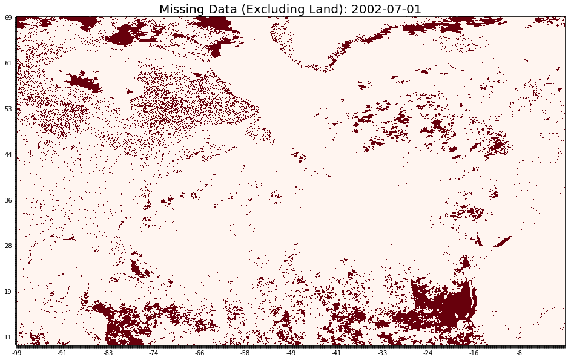

```python
fig, ax = plt.subplots(figsize=(20,10))
plt.imshow(df_adjusted, cmap='Reds', norm=colors.PowerNorm(gamma=1./1.))

plt.yticks( range(len(df_adjusted.index)), df_adjusted.index.values.astype(int) )
plt.xticks( range(len(df_adjusted.columns)), df_adjusted.columns.values.astype(float).astype(int) )

for index, label in enumerate(ax.yaxis.get_ticklabels()):
    if index % 100 != 0:
        label.set_visible(False)

for index, label in enumerate(ax.xaxis.get_ticklabels()):
    if index % 100 != 0:
        label.set_visible(False)

#plt.colorbar()
#plt.axis('off')
plt.title("Missing Data (Excluding Land): " + date, fontsize=20);
```

# Identify missing data (excluding land) at every time step

```python
def create_missing_data_frames(dataframes):

    df_adjusted_list = []

    for dataframe in tqdm(dataframes):

        df_adjusted = dataframe.copy()

        for i in range(len(land_coords_long)):
            this_lon = land_coords_long['variable'].values[i]
            this_lat = land_coords_long['lat'].values[i]
            df_adjusted.loc[this_lat,this_lon] = -1

        df_adjusted = df_adjusted.fillna(999999)
        df_adjusted_list.append(df_adjusted)

    return(df_adjusted_list)
```

```python
#%%time
#missing_data_frames = create_missing_data_frames(dataframes)
```

```python
#%%time
#with open(os.path.join('data', 'missing_dataframes.pkl'), 'wb') as f:
#    pickle.dump(missing_data_frames, f)
```

```python
pickle_in = open(os.path.join('data', 'missing_dataframes.pkl'),"rb")
missing_data_frames = pickle.load(pickle_in)
```

```python
save_frames(missing_data_frames, dates, title = "Missing Data (Excluding Land)", figsize=(20,10),
            frames_dir="frames_missing_data", cmap="Reds", gamma = 1.0,
            color_bar=False, pct_missing=True)
```

```python
make_gif("missing_data", "frames_missing_data", "movies")
```

```python
Image("https://media.giphy.com/media/Y1BQMTRLbOQBLT8NgM/giphy-downsized-large.gif")
```